# eprs_v7.0_documentation

## 1 Replication Server

EDB Postgres Replication Server (EPRS) provides a robust data platform that replicates between PostgreSQL databases in single-master or multi-master mode, or from non-PostgreSQL databases to PostgreSQL in single-master mode.

## 2 Introduction

This document describes the installation, configuration, architecture, and operation of Replication Server. Replication Server is an asynchronous replication system available for PostgreSQL and for EDB Postgres Advanced Server. The latter will be referred to simply as Advanced Server.

Replication Server can be used to implement replication systems based on either of two different replication models – single-master (primary-to-secondary) replication or multi-master replication.

Regardless of the chosen replication model, Replication Server is extremely flexible and easy to use.

For single-master replication, PostgreSQL, Advanced Server, Oracle, and Microsoft SQL Server are supported in an assortment of configurations (including cascading replication) allowing organizations to utilize it in multiple use cases with a variety of benefits.

The following are some combinations of cross database replications that Replication Server supports for single-master replication:

- From Oracle to PostgreSQL
- From Oracle to Advanced Server
- From SQL Server to PostgreSQL
- From SQL Server to Advanced Server
- From Advanced Server to Oracle
- From PostgreSQL to SQL Server
- From Advanced Server to SQL Server
- Between PostgreSQL and Advanced Server
- From PostgreSQL to Oracle (WAL mode)
- From PostgreSQL to Oracle (trigger mode)

!!! Note Oracle Real Application Clusters (RAC) and Oracle Exadata are not supported by Replication Server. These Oracle products have not been evaluated nor certified with Replication Server.

For multi-master replication, Replication Server supports the following configurations:

- Between PostgreSQL database servers
- Between PostgreSQL database servers and Advanced Servers in PostgreSQL compatible mode
- Between Advanced Servers in PostgreSQL compatible mode
- Between Advanced Servers in Oracle compatible mode

The reader is assumed to have basic SQL knowledge and basic Oracle, SQL Server, or PostgreSQL database administration skills (whichever are applicable) so that databases, users, schemas, and tables can be created and database object privileges assigned.

- The remainder of Chapter Introduction describes conventions used throughout this user’s guide along with suggested sections to read based upon your purpose for using this guide.
- Chapter Overview provides an overview of Replication Server including basic replication concepts and definitions, architecture and components of Replication Server, and design guidelines for setting up a replication system.
- Chapter Installation and Uninstallation gives instructions for installing and uninstalling Replication Server.
- Chapter Introduction to the Replication Server Console provides an overview of the Replication Server Console, the graphical user interface for using Replication Server.
- Chapter Single-Master Replication Operation gives instructions for the configuration and operation of Replication Server for single-master replication systems.
- Chapter Multi-Master Replication Operation gives instructions for the configuration and operation of Replication Server for multi-master replication systems.
- Chapter Common Operations describes operations that are common to both single-master and multi-master replication systems.
- Chapter Replication Server Command Line Interface describes the Replication Server Command Line Interface, an alternative to the graphical user interface for Replication Server configuration and management.
- Chapter Data Validator gives instructions for configuration and usage of the Data Validator.
- Chapter Appendix is an appendix containing troubleshooting tips, a list of error messages, their causes and resolutions, permitted combinations of database servers in a replication system, Replication Server product upgrade procedures, and other miscellaneous technical information.

## 2.1 Conventions Used in this Guide

The following is a list of other conventions used throughout this document.

- This guide applies to both Linux and Windows systems. Directory paths are presented in the Linux format with forward slashes. When working on Windows systems, start the directory path with the drive letter followed by a colon and substitute back slashes for forward slashes.
- Much of the information in this document applies interchangeably to PostgreSQL and EDB Postgres Advanced Server. The term Postgres is used to generically refer to both PostgreSQL and Advanced Server. When a distinction needs to be made between these two database systems, the specific names, PostgreSQL or Advanced Server are used.
- The installation directory path of the PostgreSQL or Advanced Server products is referred to as `POSTGRES_INSTALL_HOME`. For PostgreSQL Linux installations, this defaults to `/opt/PostgreSQL/x.x` for version `10` and earlier. For later versions, use the PostgreSQL community packages. For PostgreSQL Windows installations, this defaults to `C:\Program Files\PostgreSQL\x.x`. For Advanced Server Linux installations accomplished using the interactive installer for version 10 and earlier, this defaults to `/opt/PostgresPlus/x.xAS or /opt/edb/asx.x`. For Advanced Server Linux installations accomplished using an RPM package, this defaults to `/usr/ppas-x.x or /usr/edb/asx.x`. For Advanced Server Windows installations, this defaults to `C:\Program Files\PostgresPlus\x.xAS` or `C:\Program Files\edb\asx.x`. The product version number is represented by `x.x` or by `xx` for version `10` and later.

## 2.2 Certified and Supported Product Versions

The following database product versions may be used with Replication Server:

- PostgreSQL versions 9.6, 10, 11, 12, 13 and 14
- Advanced Server versions 9.6, 10, 11, 12, and 13
- Oracle 10g Release 2 version 10.2.0.1.0 has been explicitly certified. Newer minor versions in the 10.2 line are supported as well.
- Oracle 11g Release 2 version 11.2.0.2.0 has been explicitly certified. Newer minor versions in the 11.2 line are supported as well.
- Oracle 12c version 12.1.0.2.0 has been explicitly certified. Newer minor versions in the 12.1 line are supported as well.
- Oracle 18c version 18.1.0.2.0 has been explicitly certified. Newer minor versions in the 18.1 line are supported as well.
- Oracle 19c version 19.1.0.2.0 has been explicitly certified. Newer minor versions in the 19.1 line are supported as well.
- SQL Server 2008 version 10.50.1617.0 has been explicitly certified. Newer minor versions in the 10.50 line are supported as well.
- SQL Server 2012 version 11.0.6020.0 has been explicitly certified. Newer minor versions in the 11.0 line are supported as well.
- SQL Server 2014 version 12.0.5000.0 has been explicitly certified. Newer minor versions in the 12.0 line are supported as well.

Contact your EnterpriseDB Account Manager or sales@enterprisedb.com if you require support for other platforms.

**A Note Regarding Oracle RAC and Oracle Exadata**

Replication server has not been tested and is not officially supported for use with Oracle RAC and Exadata, but may work when connected to a single persistent node. To determine its ability to work with RAC or Exadata, please contact your EDB representative.

## 2.3 Supported JDK Versions

The Replication Server is certified to work with the following Java platforms:

**Table-1: Certified Java Platforms**

| **Operating Systems** | **JDK Versions** |
| --- | --- |
| `CentOS 7 and 8` | Red Hat OpenJDK 8 |
| `PPCLE RHEL7` | Red Hat OpenJDK 8 |
| `RHEL 7` | - Red Hat OpenJDK 8 - Oracle JDK 8 |
| `Windows 2012 R2, 2016, and 2019` | Red Hat OpenJDK 8 |
| `Debian 10` | Red Hat OpenJDK 11 |
| `Ubuntu 18 and 20` | OpenJDK 11 |
| `Debian 9` | OpenJDK 8 |

**Certified Java Platforms**

!!! Note Replication Server 7.0 is no longer supported on `CentOS/RHEL/OL 6.x` platforms. It is strongly recommended that EDB products running on these platforms should be migrated to a supported platform.

## 3 Overview

This chapter defines basic replication terms and concepts, and presents an overview of the components and architecture of Replication Server. The chapter concludes with design guidelines and directions for implementing a replication system using Replication Server.

## 3.1 Why Use Replication

Replication of data can be employed in a variety of use cases in organizations where it is important to use the same data in multiple settings. This allows users to work with ‘real’ data that will yield ‘real’ results that are reliable in more than one setting. Support of both single-master and multi-master replication gives Replication Server a broad range of supported use cases.

Some of the more popular uses of single-master replication include the following:

## 3.1.1 Offloading Reporting and Business Intelligence Queries

In this use case, users take all or just a subset of data from a production OLTP system and replicate it to another database whose sole purpose is to support reporting queries. This can have multiple benefits:

1. Reporting loads are removed from the OLTP system, improving transaction processing performance.
2. Query performance improves as well without being subordinated to transactions on the system.
3. In Oracle installations, the reporting server duties can be handled by a product like Advanced Server reducing licensing costs for a reporting server.

## 3.1.2 Using Warm Standby Servers

When many organizations wish to improve the availability of their data, a cost effective solution is often the use of warm standby servers. These are database servers kept up to date with the online system through replication that can be brought online quickly in the event of a failure in the production system. Warm standby servers can also be used for regular maintenance by gracefully switching over to the standby server so that the production server can be brought offline for regular maintenance.

## 3.1.3 Testing Systems in Parallel

Often times, upgrading or moving to a new database system requires that the old and new systems be up and running in parallel to allow for testing and comparing results in real time. Replication can be employed in this use case and is frequently used in development and testing environments.

## 3.1.4 Migrating Data

Similar to running in parallel, is the situation where data may be migrated from one system to another in a sort of *seeding* operation. Replication can be very effective in this situation by quickly copying data.

Some reasons to consider multi-master replication include the following:

## 3.1.5 Write Availability

In single-master replication, only the primary database is available for writes. The secondary databases are read-only for applications. If the replicated target databases must be available for write access as well, multi-master replication can be employed for the same use cases as outlined for single-master replication, but with the additional advantage of write access to the secondary.

## 3.1.6 Write Scalability

In write-intensive applications, multi-master replication allows you to utilize multiple database servers on separate hosts to process write transactions independently of each other on their own primary databases. Changes can then be reconciled across primary databases according to your chosen schedule.

## 3.1.7 Localized Data Access

In a geographically dispersed application, local access to the database can be provided to regions of clients. Having the database servers physically close to clients can reduce latency with the database. Multi-master replication allows you to employ a WAN connected network of primary databases that can be geographically close to groups of clients, yet maintain data consistency across primary databases.

## 3.2 Replication Concepts and Definitions

Replication Server is a software product that enables the implementation of a replication system. A **replication system** is software and hardware whose purpose is to make a copy of data from one location to another and to ensure the copied data is the same as the original over time.

Replication Server applies the replication system concept to tables of Oracle, SQL Server, PostgreSQL, and Advanced Server database management systems.

The following sections present specific terms and concepts used when discussing Replication Server.

## 3.2.1 Comparison of Single-Master and Multi-Master Replication

There are two models of replication systems supported by Replication Server:

- **Single-Master Replication (SMR).** Changes (inserts, updates, and deletions) to table rows are allowed to occur in a designated primary database. These changes are replicated to tables in one or more secondary databases. The replicated tables in the secondary databases are not permitted to accept any changes except from its designated primary database. (This is also known as primary-to-secondary replication.)
- **Multi-Master Replication (MMR).** Two or more databases are designated in which tables with the same table definitions and initial row sets are created. Changes (inserts, updates, and deletions) to table rows are allowed to occur in any database. Changes to table rows in any given database are replicated to their counterpart tables in every other database.

For a single-master replication system, a variety of configurations are supported including:

- Replication between PostgreSQL and Advanced Server databases (between products in either direction)
- Replication in either direction between Oracle and Advanced Server
- Replication in either direction between SQL Server and PostgreSQL
- Replication in either direction between SQL Server and Advanced Server
- Replication in either direction between PostgreSQL and Oracle

For multi-master replication, the participating database servers in a given multi-master replication system must be of the same type:

- PostgreSQL database servers
- PostgreSQL database servers and Advanced Servers operating in PostgreSQL compatible mode
- Advanced Servers operating in PostgreSQL compatible mode
- Advanced Servers operating in Oracle compatible mode

!!! Note A given database cannot simultaneously participate in both a single-master replication system and a multi-master replication system.

## 3.2.2 Publications and Subscriptions

Replication Server uses an architecture called *publish* and *subscribe*. The data to be made available for copying by a replication system is defined as a publication. To get a copy of that data, you must `subscribe` to that publication. The manner in which you subscribe is slightly different for single-master and multi-master replication systems.

In Replication Server a publication is defined as a named set of tables and views within a database. The database that contains the publication is called the publication database of that publication.

In a single-master replication system, to get a copy of an Replication Server publication, you must create a subscription. A Replication Server subscription is a named association of a publication to a database to which the publication is to be copied. This database is called the subscription database.

Similar to a single-master replication system, when creating a multi-master replication system, you first define a publication in the publication database. You then add one or more additional databases that you want to participate in this multi-master replication system. As you add each database, it is associated with this replication system. You do not create an explicit, named subscription in a multi-master replication system.

In a single-master replication system, replication is said to occur when Replication Server initiates and completes either of the following processes:

1. applies changes that have been made to rows in the publication since the last replication occurred, to rows in tables of the subscription database (called synchronization); or
2. copies rows of the publication to empty tables of the subscription database (called a snapshot). See Snapshot and Synchronization Overview for further discussion on snapshots and synchronization.

The subscription tables are the tables in the subscription database created from corresponding tables or views in the publication.

!!! Note In a single-master replication system Replication Server creates a table in the subscription database for each view contained in the publication.

In a multi-master replication system, the concept and definition of replication is nearly identical to a single-master replication system with the following modifications:

1. synchronization can occur between any pair of databases (referred to as primary nodes) participating in the replication system;
2. a snapshot can occur from the publication database designated as the Primary Definition Node to any of the other primary nodes.

The following diagrams illustrate some basic single-master replication system examples.

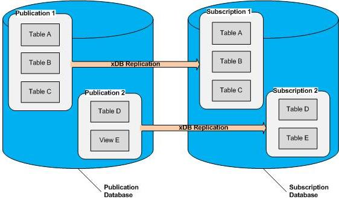

**Figure 2-1: Publications in one database replicating to subscriptions in another database**

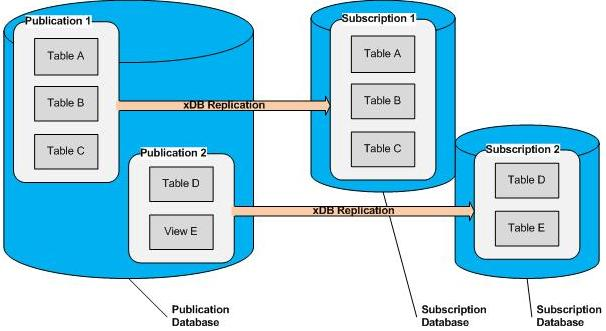

**Figure 2-2:Publications replicating to two subscription databases**

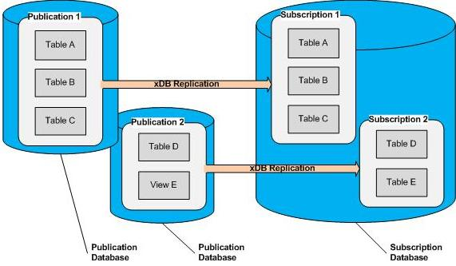

**Figure 2-3: Publications in two databases replicating to one subscription database**

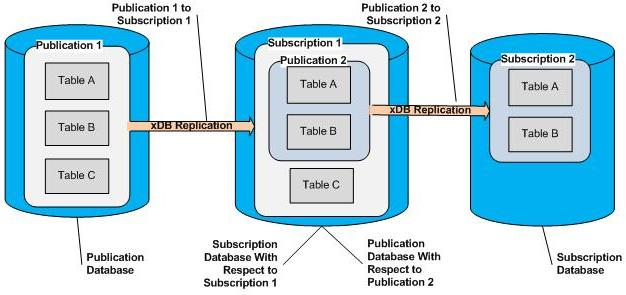

**Figure 2-4: Cascading Replication: Tables used in both a subscription and a publication**

The preceding diagram illustrates that a table that has been created as a member of a subscription can be used in a publication replicating to another subscription. This scenario is called cascading replication.

The following diagram illustrates a multi-master replication system with three primary nodes.

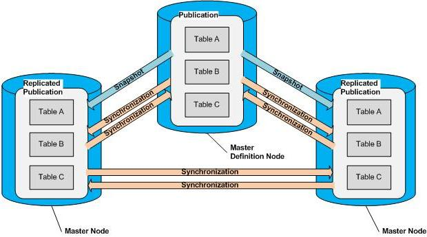

**Figure 2-5: Multi-master replication system**

## 3.2.3 Single-Master (Primary-to-secondary) Replication

Replication Server performs primary-to-secondary replication when a single-master replication system is implemented. The publication is the master and the subscription is the secondary. In a primary-to-secondary relationship, changes are propagated in one direction only, from the master to the secondary.

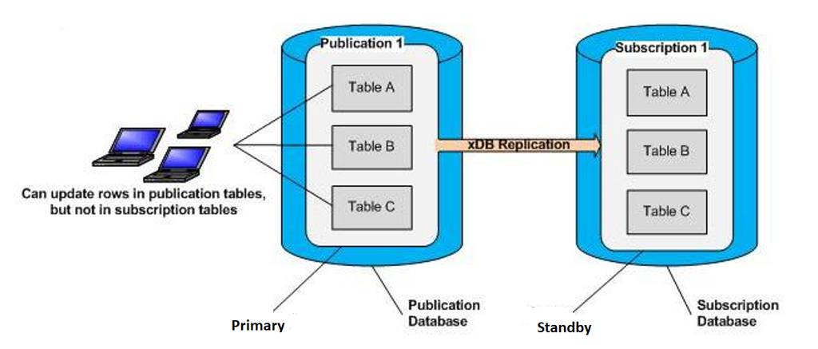

**Figure 2-6: Single-Master (Primary-to-secondary) replication**

Generally, changes must not be made to the definitions of the publication tables or the subscription tables. If such changes are made to the publication tables, they are not propagated to the subscription and vice versa unless the DDL change replication feature is used as described in Replicating DDL Changes. If changes are made to the table definitions without using the DDL change replication feature, there is a risk that future replication attempts may fail.

Changes must not be made to the rows of the subscription tables. If such changes are made, they are not propagated back to the publication. If changes are made to the subscription table rows, it is fairly likely that the rows will no longer match their publication counterparts. There is also a risk that future replication attempts may fail.

## 3.2.4 Multi-Master Replication

As an alternative to the single-master (primary-to-secondary) replication model, Replication Server supports multi-master replication.

The following definitions are used when referring to multi-master replication systems.

A primary node is a database participating in a multi-master replication system.

The database (primary node) in which the publication is initially defined is specially designated as the `primary definition node (PDN)`. There can be only one primary definition node at any given time, however, it is possible to change which primary node is the primary definition node. When it is important to make a distinction between the primary definition node and all other primary nodes that are not the primary definition node, the latter are referred to as `non-PDN nodes`.

The primary definition node has the following significance:

- The publication is initially created in the primary definition node, and the tables comprising the publication must exist in the database to be designated as the primary definition node at the time the publication is defined.
- The publication can be initially replicated to other primary nodes by means of a snapshot from the primary definition node.
- Each subsequent primary node added to the replication system must either: 1) contain no tables with the same schema-qualified names as the publication tables in the primary definition node; or 2) contain all publication table definitions as they exist in the primary definition node with the same schema-qualified names. In the first case, when you add the primary node, you select the option to replicate the publication schema from the primary definition node. In the second case, you do not select this option.
- The table rows in a primary node can be reloaded from the primary definition node. The primary node tables are truncated and the rows reloaded by a snapshot from the primary definition node.

Once the multi-master replication system is defined, changes (inserts, updates, and deletions) to rows of the publication tables on any primary node are synchronized to all other primary nodes on either an on demand or scheduled basis.

Generally, changes must not be made to the table definitions in any of the primary nodes including the primary definition node. If such changes are made, they are not propagated to other nodes in the multi-master replication system unless they are made using the DDL change replication feature described in Replicating DDL Changes. If changes are made to tables without using the DDL change replication feature, there is a risk that future replication attempts may fail.

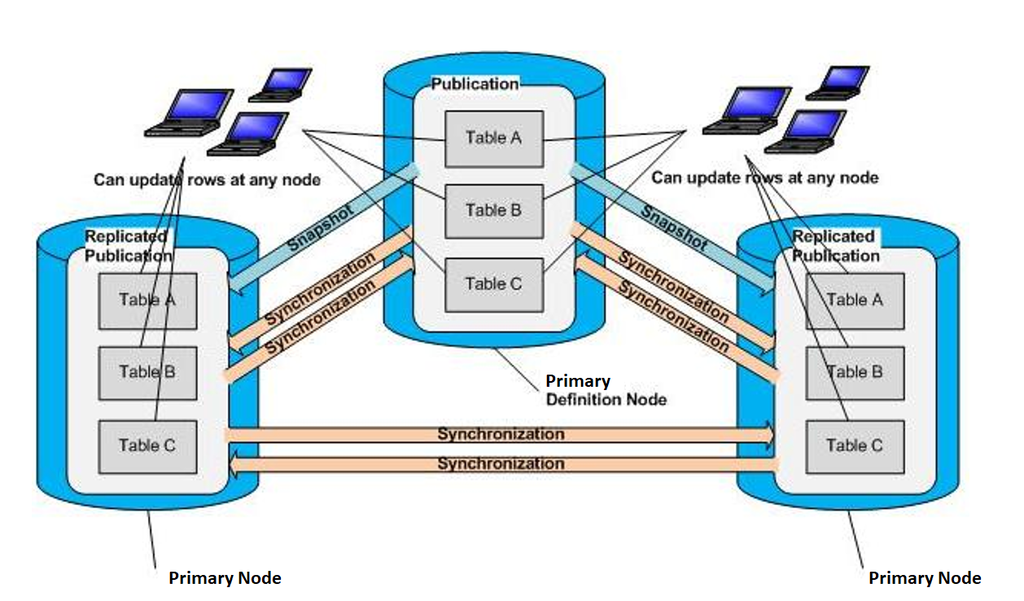

**Figure 2-7: In a multi-master replication system, table rows can be updated at any primary node**

## 3.2.5 Asynchronous

Replication Server performs replications asynchronously. The systems hosting the databases do not always have to be running continuously in order for successful replication to occur. If one system goes offline, replication resumes when it comes back online if there is still pending data to replicate.

In addition you can create a schedule for your replication system. Replication Server initiates and performs replications regularly according to the assigned schedule. This allows you to run the replication system unattended. See Creating a Schedule for directions on creating a schedule.

## 3.2.6 Snapshot and Synchronization Overview

Replication Server performs two different types of replications. These two main types are called snapshot replication and synchronization replication.

In either method, the source tables refer to the tables from which the replication data is originating (the publication in a single-master replication system, or the primary node whose changes are being replicated to another primary node in a multi-master replication system).

The target tables are the tables that are receiving the replication data from the source tables (the subscription tables in a single-master replication system, or the primary node receiving changes from another primary node in a multi-master replication system).

In snapshot replication, all existing rows in the target tables are deleted using the database system’s `TRUNCATE` command. The tables are then completely reloaded from the source tables of the publication.

In synchronization replication, only the changes (inserts, updates, and deletions) to the rows in the source tables since the last replication are applied to the target tables.

!!! Note Deletion of all rows in a source table executed by the `SQL TRUNCATE` command results in replication to the target tables only if the log-based method of synchronization replication is used. If the trigger-based method of synchronization replication is used, execution of the `TRUNCATE` command on a source table does not replicate the effect to the target tables. You must perform a snapshot from the source table to the target tables if the trigger-based method is used. (The difference between the trigger-based method and the log-based method is discussed as follows.)

Synchronization replication is implemented using two different methods – the trigger-based method and the log-based method.

In the trigger-based method changes to rows in the source tables result in the firing of row-based triggers. These triggers record the changes in shadow tables. The changes recorded in the shadow tables are then periodically extracted from the shadow tables, converted to an in-memory data structure, and applied to the target tables by means of SQL statements executed using JDBC. See Synchronization Replication with the Trigger-Based Method for information on the trigger-based method.

In the log-based method changes to rows in the source tables are extracted from the Write-Ahead Log segments (WAL files) using asynchronous streaming replication implemented by the logical decoding feature available in Postgres database servers. The extracted changes are converted to an in-memory data structure and applied to the target tables by means of SQL statements executed using JDBC. See Synchronization Replication with the Log-Based Method for information on the log-based method.

In a multi-master replication system, the manner in which changes accumulated on all primary nodes are replicated to all other primary nodes is conceptually done in groups identified by the source primary node with the changes to be replicated. See Multi-Master Parallel Replication for information on this process and the improvement for the log-based method with parallel replication.

In a single-master replication system, the very first replication to a newly created subscription must always be done by a snapshot. Subsequent replications can be done by snapshot or by synchronization provided that the publication is not defined as a snapshot-only publication as discussed in Snapshot-Only Publications.

In a multi-master replication system, the very first replication from the primary definition node to a newly added primary node must always be done by a snapshot. Subsequent replications between primary nodes occur by synchronization. However, it is possible to perform subsequent snapshots from the primary definition node to any other primary node.

## 3.2.7 Snapshot-Only Publications

When a publication is created in a single-master replication system, the publication can be defined as a snapshot-only publication. Replication from a snapshot-only publication can only be done using the snapshot replication method. Synchronization replication is not permitted on a snapshot-only publication.

A snapshot-only publication cannot be created in a multi-master replication system.

See Performance Considerations for a discussion of the advantages of using a snapshot-only publication.

## 3.2.8 Snapshot Replication

In snapshot replication, the target tables are completely reloaded from the source tables. The database system’s truncate operation is used to delete all rows from the target tables.

**For Oracle and SQL Server only:** Oracle and SQL Server target tables are loaded using JDBC batches of `INSERT` statements.

**For Postgres only:** In general, Postgres target tables are loaded using the JDBC COPY command since using truncation and COPY is generally faster than if you were to execute an `SQL DELETE` statement against the entire table and then add the rows using JDBC batches of `INSERT` statements. If the `COPY` command fails, the publication server retries the snapshot using JDBC batches of `INSERT` statements.

If the target table (regardless of database type) contains a large object data type such as `BYTEA`, `BLOB`, or `CLOB` then rows are loaded one at a time per batch using an INSERT statement. This is to avoid a heap space error resulting from potentially large rows. Loading time can be decreased by allowing multiple inserts per batch, which is done by adjusting the configuration option `lobBatchSize` described in Optimizing Snapshot Replication.

!!! Note Advanced Server supports a number of aliases for data types. Such aliases that translate to `BYTEA` are treated as large object data types. See the Database Compatibility for Oracle Developers Reference Guide for a listing of Advanced Server data types. (See the *Database Compatibility for Oracle Developer’s Guide* for Advanced Server version 9.5 or earlier versions.)

Under certain circumstances, the corresponding Postgres target table created for certain types of Oracle partitioned tables is a set of inherited tables. In these cases, the `SQL DELETE` statement is used on the inherited child tables instead of truncation. See Replicating Oracle Partitioned Tables for additional information on replicating Oracle partitioned tables.

A server configuration option is available that forces the snapshot replication process to use the Oracle database link utility instead of `JDBC COPY` to populate the Postgres target tables from an Oracle publication. Oracle database link provides an additional performance improvement over `JDBC COPY`. See Optimizing Snapshot Replication for information on using the Oracle database link option.

See Optimizing Snapshot Replication for information on various configuration options to optimize snapshot replication.

## 3.2.9 Synchronization Replication with the Trigger-Based Method

If a publication in a single-master replication system is created that will be used in synchronization replications with the trigger-based method, the publication server installs an insert trigger, an update trigger, and a delete trigger on each publication table. In a multi-master replication system, each replicated table in each primary node employing the trigger-based method has an insert trigger, an update trigger, and a delete trigger.

The publication server also creates a shadow table for each source table on which triggers have been created. A shadow table is a table used by Replication Server to record the changes (inserts, updates, and deletions) made to a given source table. A shadow table records three types of record images:

- For each row inserted into the source table, the shadow table records the image of the inserted row.
- For each existing row that is updated in the source table, the shadow table records the after image of the updated row.
- For each row deleted from the source table, the shadow table records the identity columns (primary key or unique columns) value of the deleted row.

!!! Note In a multi-master replication system, the before image of an updated row is also stored in the shadow table in order to perform update conflict detection. See Conflict Resolution for information on conflict detection in a multi-master replication system.

After each change on the source table, one of the insert, update, or delete triggers is executed. These are row triggers, so for each row affected by the change, the trigger executes. Each execution of the trigger records a row of the appropriate type (insert, update, or deletion) in the shadow table of the corresponding source table.

Though changes made to the source tables since the last replication occurred are applied to the target tables using `SQL INSERT, UPDATE`, and `DELETE` statements, the actual SQL statements run against the target tables are not the same SQL statements that were run against the source tables.

When synchronization replication occurs, the publication server executes JDBC batches of SQL statements (also referred to as transaction sets) against the target tables. The batches contain an `INSERT` statement for each shadow table row recording an insert operation, an `UPDATE` statement for each shadow table row recording an update operation, and a `DELETE` statement for each shadow table row recording a delete operation. Each batch is executed in one transaction.

Shadow table rows that were applied to target tables can be viewed as shadow table history in the Replication Server Console (see Shadow Table History).

!!! Note A single SQL statement executed against a source table may result in many rows recorded in a shadow table, and therefore, many SQL statements executed against the target table. For example, if a single `UPDATE` statement affects 10 rows in the source table, 10 rows will be inserted into the shadow table – one for each row in the source table that was updated. When the publication server applies the changes to the target table, 10 `UPDATE` statements will be executed.

!!! Note For greater efficiency, when changes to the source tables consist of SQL statements that each affect a large number of rows, the publication server may employ the use of prepared SQL statements. See Optimizing Synchronization Replication for directions on how to control the usage of prepared SQL statements as well as information on various other configuration options to optimize synchronization replication.

## 3.2.10 Synchronization Replication with the Log-Based Method

In PostgreSQL 9.4 a feature has been introduced called logical decoding (also called logical replication or changeset extraction). This feature provides the capability to extract data manipulation language (DML) changes from the Write-Ahead Log segments (WAL files) in a readable format.

For information on logical decoding see the *PostgreSQL Core Documentation* located at:

> https://www.postgresql.org/docs/current/static/logicaldecoding.html

The key significance of this feature is the ability to capture data changes to the publication tables without impacting the online transaction processing rate against these tables that occurs when using the trigger-based method. The trigger-based method results in the firing of row-level triggers whenever data changes occur, then inserting these data changes into shadow tables for temporary storage before applying the changes to the target databases.

Thus, extracting data changes using logical decoding can be beneficial for improving database server throughput and replication latency.

However, note that the logical decoding interface streams changes for all tables in a given database, which may have a performance overhead associated with it. For example, if a database contains 100 tables, and the user is interested in replicating only a small subset of these tables, say only 20 tables in a single publication, the logical decoding protocol will stream changes for all 100 tables to the publication server. The publication server eventually filters out the changes for the irrelevant 80 tables. However, this results in network overhead caused by the additional changeset load that is not required by the replication system.

Using logical decoding to extract changes from a publication database during EPRS synchronization replication is referred to as the log-based method.

The following sections describe the basic requirements and concepts for the log-based method of synchronization replication.

## 3.2.10.1 Requirements and Restrictions

The following are the general requirements and restrictions when using the log-based method for any database of a single-master or multi-master replication system:

- The selection of either the trigger-based method or the log-based method is a characteristic applicable to only the publication database. The choice is made when defining the primary database of a single-master replication system (see Section Adding a Publication Database) or the primary definition node of a multi-master replication system (see Adding the Primary definition node).
- The logical decoding feature, and hence the log-based method, is supported beginning with PostgreSQL version 9.4. Therefore, in order to use the log-based method for a publication database, that publication database must be running under PostgreSQL version 9.4 or later, or under Advanced Server version 9.4 or later.
- In a single-master replication system, whether the primary database uses the trigger-based method or the log-based method has no additional impact on the rules for choosing the subscription database. For example, even if the log-based method is chosen for the primary database, the subscription database may be running on Postgres version 9.4 as well as any supported, earlier version of Postgres, as well as Oracle or SQL Server.
- In a single-master replication system, the primary database may contain one or more publications (that is, named sets of tables for replication). This is applicable to a primary database using either the trigger-based method or the log-based method.
- It is permissible to have multiple, single-master replication systems running under a publication server where some primary databases may use the trigger-based method while others use the log-based method.
- In a multi-master replication system, the selection of either the trigger-based method or the log-based method on the primary definition node determines the method for all other primary nodes. In other words, if the trigger-based method is chosen for the primary definition node, then all other primary nodes will use the trigger-based method. If the log-based method is chosen for the primary definition node, then all other primary nodes will use the log-based method.
- As a consequence of the restriction described in the preceding bullet point, in order to use the log-based method for a multi-master replication system, all of the primary nodes of the system must be running under Postgres version 9.4 or later, and all such Postgres database clusters must be configured to use logical decoding for the log-based method.

Selection of the log-based method for any database impacts the configuration of the Postgres database cluster containing that database.

If you plan to use the log-based method with any publication database running under a Postgres database server, the following configuration parameter settings are required in the configuration file, `postgresql.conf`, of that Postgres database server:

- `wal_level.` Set to logical.
- `max_wal_senders.` Specifies the maximum number of concurrent connections (that is, the maximum number of simultaneously running WAL sender processes). Set at minimum, to the total number of primary databases of single-master replication systems and primary nodes of multi-master replication systems on this database server that will use the log-based method.
- `max_replication_slots.` Specifies the maximum number of replication slots. If the database server supports both single-master replication systems and multi-master replication systems, then max_replication_slots must be set at minimum to the sum of the requirements for both replication systems. For support of SMR systems, the minimum requirement is the total number of primary databases of the single-master replication systems that will use the log-based method. For support of MMR systems, the minimum requirement is the total number of primary nodes in the multi-master replication system multiplied by the number of primary nodes residing on this database server. For information, see Replication Origin.
- `track_commit_timestamp.` Set to `on`. This configuration parameter applies only to Postgres database servers of version 9.5 and later. See Configuration Parameter and Table Setting Requirements for additional information.

Also, see Enabling Synchronization Replication with the Log-Based Method for setting these parameters for a single-master replication system. See Enabling Synchronization Replication with the Log-Based Method for a multi-master replication system.

In addition, the `pg_hba.conf` configuration file of the Postgres database server must contain an entry permitting `REPLICATION` access for each database using the log-based method running on the database server. The access must be permitted to the publication database user specified when creating the publication database definition using the Replication Server Console (See Adding a Publication Database for a single-master replication system or Adding the Primary definition node for a multi-master replication system) or the Replication Server Command Line Interface (CLI) (see Adding a Publication Database (addpubdb)).

See Postgres Server Authentication for setting `REPLICATION` access for a single-master replication system. See Verifying Host Accessibility for a multi-master replication system.

For configuration options in the publication server configuration file that are specifically applicable to the log-based method see Log-Based Method of Synchronization Options.

## 3.2.10.2 Logical Replication Slots

When using the log-based method on a publication database, the underlying logical decoding framework exposes the data changes (the changeset stream) by means of a logical replication slot.

A logical replication slot represents a changeset stream and applies to a single database. The Replication Server assigns a unique identifier, called the slot name, to each logical replication slot it creates in the form xdb_dboid_pubid where `dboid` is the publication database object identifier (`OID`) and `pubid` is the publication ID assigned by the Replication Server. All slot names are unique within a Postgres database cluster.

Thus, for each single-master replication system using the log-based method, a replication slot is required for the publication database of each such system.

For a multi-master replication system using the log-based method, each primary node requires a replication slot.

The maximum number of replication slots permitted for a database server is controlled by the `max_replication_slots` configuration parameter in the `postgresql.conf` file. Therefore this configuration parameter must be set to a large enough value to account for all publication databases defined with the log-based method of single-master replication systems running on the database server as well as all primary nodes of a multi-master replication system defined with the log-based method running on the database server. Additional replication slots are required to support the usage of replication origin (see Replication Origin). See Enabling Synchronization Replication with the Log-Based Method for additional information on configuration parameters for single-master replication systems. See Enabling Synchronization Replication with the Log-Based Method for multi-master replication systems.

## 3.2.10.3 Streaming Replication with the WAL Sender Process

The changeset stream is accessible to the EPRS publication server by the **WAL sender process** (`walsender`) using the streaming replication protocol.

The EPRS publication server connects using the `walsender` interface through which changes are streamed on a continual basis. The continuous streaming eliminates the need for explicitly polling for changes.

The following are the basic synchronization steps using the log-based method:

1. A streaming replication connection to the database server is opened using `libpq` to establish a `walsender` communication channel.
2. A separate thread is used to monitor data changes streamed through the `walsender` interface.
3. As the data changes become available, they are transformed to populate an in-memory cache.
4. On the next scheduled interval, the in-memory cached data changes are applied to each of the target databases in JDBC batches of SQL statements (referred to as transaction sets) in the same manner as described in Synchronization Replication with the Trigger-Based Method for the trigger-based method. If one or more target database servers are not accessible, the data changes are saved in a local file on the host running the publication server. See In-Memory Caching and Persistence for information on in-memory caching and data persistence.
5. The value of the `WAL` segment’s log sequence number (`LSN`) identifying the last set of applied changes based on the last replicated transaction is updated. The update is confirmed to the database server.
6. The applied data changes are cleared from the in-memory cache.
7. Steps 3 through 6 are repeated.

!!! Note A single SQL statement executed against a source table may result in many rows modified and returned in the changeset stream, and therefore, many SQL statements executed against the target table. For example, if a single `UPDATE` statement affects 10 rows in the source table, 10 rows will be returned in the changeset stream – one for each row in the source table that was updated. When the publication server applies the changes to the target table, 10 `UPDATE` statements will be executed.

## 3.2.10.4 Replication Origin

Starting with Postgres version 9.5, a feature called replication origin has been introduced to the logical decoding framework. Replication origin allows an application to identify, label, and mark certain aspects of a logical decoding session.

For information on replication origin see the *PostgreSQL Core Documentation* located at:

> https://www.postgresql.org/docs/current/static/replication-origins.html

For the log-based method of synchronization replication, this provides performance improvement provided that the primary nodes are running under Postgres version 9.5 or later.

As previously described, the log-based method uses the WAL files to obtain the changes applied to the publication tables. After the changes are retrieved through the walsender interface, the publication server applies the set of changes to the other primary nodes using transaction sets consisting of JDBC batches of SQL statements. When these changes are applied to the tables in the other target primary nodes, the same changes are also recorded in the WAL files of each database server hosting the target primary nodes.

These redundant or `replayed` changes are included in the changeset stream received by the publication server. These replayed changes must be ignored and not applied since they are duplicates of all changes that have already been applied to the target tables through the JDBC batches.

The replayed changes result in performance overhead as all such changes are transmitted over the network from the database server to the publication server, and then the publication server must discard such redundant changes.

With the replication origin feature, the publication server is able to set up the logical decoding sessions so that these replayed changes are not included in the changeset stream transmitted over the network to the publication server thus eliminating this performance overhead.

The following are the conditions under which replication origin is used:

- Replication origin applies to multi-master replication systems only, not to single-master replication systems.
- Replication origin eliminates streaming of replayed changes only from Postgres versions 9.5 or later. Replayed changes are still included in the changeset stream from Postgres version 9.4, but are discarded by the publication server. Thus multi-master replication systems consisting of both Postgres versions 9.4 and 9.5 utilize the replication origin advantage on the 9.5 database servers.
- The `max_replication_slots` configuration parameter must be set at a certain minimal level to ensure that the publication server can create the additional replication slots for replication origin.

For each primary node database, in addition to the replication slot used for the changeset stream, an additional number of replication slots is required – one additional slot corresponding to every other primary node to support the replication origin usage. Thus, for each primary node, the total number of replication slots required is equal to the total number of primary nodes in the entire MMR system.

Therefore, for a given database server (that is, a Postgres database cluster containing primary node databases), the total number of replication slots required is equal to the total number of primary nodes in the entire MMR system multiplied by the number of primary node databases residing within the given database cluster.

For example, assume the usage of a 6-node multi-master replication system using three database clusters as follows:

- Database cluster #1 contains 3 primary node databases.
- Database cluster #2 contains 2 primary node databases.
- Database cluster #3 contains 1 primary node database.

The total number of primary nodes is six. Multiply the number of primary node databases in each database cluster by six to give the required minimum setting for `max_replication_slots` for that database cluster.

The following table shows the required, minimum settings for `max_replication_slots` as well as `max_wal_senders`.

**Table 2-1: Replication Origin Configuration Parameter Settings**

| **Postgres Database Server** | **max_wal_senders** | **max_replication_slots** |
| --- | --- | --- |
| Cluster #1 (3 primary nodes) | 3 | 18 |
| Cluster #2 (2 primary nodes) | 2 | 12 |
| Cluster #3 (1 primary node) | 1 | 6 |

If the `max_replication_slots` parameter is not set to a high enough value, synchronization replication still succeeds, but without the replication origin performance advantage.

The publication server log file contains the following warning in such cases:

```
WARNING: Failed to setup replication origin ``xdb_MMRnode_c_emp_pub_6``. Reason: ERROR: could not find free replication state slot for replication origin with OID 4
  Hint: Increase max_replication_slots and try again.
```

The following example shows some of the replication slot information for a 3-primary node system running on a single database cluster.

The following shows the maximum allowable number of replication slots:

```
SHOW max_replication_slots;

max_replication_slots
-----------------------
 9
(1 row)
```

The number should be sufficiently greater than the number of replication slots and replication origins currently allocated.

The following displays the replication slots:

```
SELECT slot_name, slot_type, database, active FROM pg_replication_slots ORDER BY 1;

  slot_name  | slot_type | database  | active
-------------+-----------+-----------+--------
 xdb_47877_5 | logical   | MMRnode_a | t
 xdb_47878_5 | logical   | MMRnode_b | t
 xdb_47879_5 | logical   | MMRnode_c | t
(3 rows)
```

The following shows the replication origins.

```
SELECT * FROM pg_replication_origin ORDER BY 2;

 roident |          roname
---------+--------------------------
       5 | xdb_MMRnode_a_emp_pub_39
       2 | xdb_MMRnode_a_emp_pub_6
       1 | xdb_MMRnode_b_emp_pub_1
       6 | xdb_MMRnode_b_emp_pub_39
       3 | xdb_MMRnode_c_emp_pub_1
       4 | xdb_MMRnode_c_emp_pub_6
(6 rows)
```

The replication origin name is assigned in the format `xdb_srcdbname_pubname_remotedbid` where `srcdbname` is the source database name, `pubname` is the publication name, and `remotedbid` is the publication database ID of a remote database.

The replication slots are in the active state when the publication server is running. The replication slots are deactivated when the publication server is shut down.

The replication slots and replication origin sessions are deleted from the database cluster when their corresponding primary nodes are removed from the multi-master replication system using the Replication Server Console or the Replication Server CLI.

Should some situation occur where the replication slots are not properly deleted when required, see Dropping Replication Slots for Log-Based Synchronization Replication for instructions on manually deleting them.

## 3.2.10.5 In-Memory Caching and Persistence

The data changes are fetched and stored in memory buffers to optimize the data replication process. This avoids the overhead associated with repeatedly fetching the same set of changes from the database server when there are multiple target databases.

This approach is sufficient as long as all of the target databases are accessible during a replication event and the data fits within the available cache.

However, if one or more of the target databases is unavailable due to network connectivity problems, server down time, etc. the in-memory data changes must be persisted for later retrieval when the target databases becomes available for synchronization with the source database.

The Replication Server architecture utilizes `Java object serializatio` to persist the in-memory state of the data. Object serialization is the conversion of object data and other relevant information to a sequence of bytes that can then be stored in a file.

The following are examples that can result in the eviction of in-memory data to persistent storage:

- Before the next replication event occurs, the in-memory cache is filled with the data changes and needs to be evicted to accommodate a new set of changes.
- In the replication system, there are multiple target databases. During a synchronization event, all of the changes available in the cache are applied successfully to some of the target databases. However one or more of the other target databases cannot be accessed. All of the applied changes held in memory must be persisted and retained so that these changes can be reloaded and applied when the inaccessible databases becomes available.

The cache size corresponds to the heap size configured for the publication server by the `-Xmxnnnm` setting of the `JAVA_HEAP_SIZE` parameter in the Replication Server Configuration file. See EPRS Replication Configuration File for information on the Replication Server Configuration file.

The persistence I/O overhead can be minimized by increasing the heap size value and defining a more frequent synchronization interval such as for every few seconds. See Creating a Schedule for information on setting a replication schedule.

The data changes are persisted in a local file on the host running the publication server. The file is stored in the directory `XDB_HOME/xdata`.

Each time persistence occurs, a new file is created. After the files have been processed, they are periodically removed from disk.

## 3.2.11 Multi-Master Parallel Replication

For a multi-master replication system, transactions can be replicated from one primary node to another by one of the synchronization methods described in the previous sections – either the trigger-based method (see Synchronization Replication with the Trigger-Based Method) or the log-based method (see Synchronization Replication with the Log-Based Method).

For a single replication event to be considered finished and complete, transactions that have occurred on all primary nodes since the previous replication event must be successfully replicated to all other primary nodes by the configured synchronization method.

This consists of a series of multiple replication sets, each identified by a primary node acting as the source primary node, which contains the transactions that needs to be replicated to all other primary nodes acting as the target primary nodes. So for a multi-master replication system consisting of n number of primary nodes, there will be n such replication sets – each with a different primary node acting as the source.

Since the initial support of multi-master replication systems in Replication Server version 5.0, such a series of multiple replication sets were always initiated in a strictly serial manner. That is, the transaction replication from a source primary node to all target primary nodes must be completed before the start of the transaction replication from the next primary node to all other target primary nodes, and so on.

For example, consider a 3-primary node system consisting of primary node A, primary node B, and primary node C.

If applications have applied transactions to tables in all three primary nodes and then a synchronization replication event is initiated either on demand by the Replication Server Console, an Replication Server CLI command, or by a scheduled replication, the transactions are replicated in the following manner:

1. Transactions that were made on primary node A are replicated to primary node B and primary node C.
2. When Step 1 has been completed, transactions that were made on primary node B are replicated to primary node A and primary node C.
3. When Step 2 has been completed, transactions that were made on primary node C are replicated to primary node A and primary node B.

The time to complete the entire replication event, referred to as the latency time, is basically the sum of the replication times where each primary node acts as the source (that is, the sum of the times for steps 1, 2, and 3).

For the log-based method, this latency time has been reduced by the implementation of parallel replication whereby each replication set from a given primary node acting as the source, executes and runs simultaneously with all other replication sets where the other primary nodes act as the source.

Thus, a replication set from a primary node is not waiting for others to complete before it can start so steps 1, 2, and 3 all run simultaneously instead of one after the other.

!!! Note The parallel replication applies only to the log-based method and not for the trigger-based method.

There is no required configuration setting to enable the use of parallel replication for the log-based MMR system.

!!! Note In addition to parallel replication, optimization of replicating from a given primary node to all other primary nodes (that is, within the context of a single replication set) has been implemented with the use of multiple threads. This is referred to as parallel synchronization. Parallel synchronization applies to both the trigger-based and log-based methods. See Parallel Synchronization for information on parallel synchronization.

## 3.2.12 Table Filters

Table filters specify the selection criteria for rows in publication tables or views that are to be included during replications to subscriptions from the publication database in a single-master replication system or between primary nodes in a multi-master replication system. Rows that do not satisfy the selection criteria are excluded from replications to subscriptions or primary nodes on which these table filters have been enabled.

### Implementing Table Filters

Implementing table filters is a two-part process. First, a set of available table filters must be defined. This can be done while creating the publication by defining specific, named rules applicable to selected publication tables or views expressed in the form of `SQL WHERE` clauses.

While simple conditions with comparison and logical operators `(=, >, <, LIKE, etc.)` are allowed as filters for all use cases, there is one use case when a more complex condition can be used as a filter. A subquery can be used in establishing an inclusion/exclusion list of IDs if a single column is returned from the subquery. This is only supported for trigger-based SMR use cases. Here are the patterns for this type of query:

```
PUBLISHED_TABLE_COLUMN_NAME IN (SELECT COLUMN_NAME FROM TABLE_NAME)

PUBLISHED_TABLE_COLUMN_NAME NOT IN (SELECT COLUMN_NAME FROM TABLE_NAME)
```

For example, if we have tables `dept` and `dept_filter_lookup` created with:

```
CREATE TABLE public.dept (

deptno NUMERIC(2) PRIMARY KEY,

dname VARCHAR(14) UNIQUE,

loc VARCHAR(13)

);

CREATE TABLE public.dept_filter_lookup (

id NUMERIC(2) PRIMARY KEY

);
```

then following filters can be used:

```
deptno IN (SELECT id FROM public.dept_filter_lookup)
```

or

```
deptno NOT IN (SELECT id FROM public.dept_filter_lookup)
```

to create a publication with the following RepCLI commands:

```
$ java -jar edb-repcli.jar -createpub  pub -repsvrfile ~/pubsvrfile -pubdbid 1 -tables public.dept -reptype T \

-tablesfilterclause "public.dept:lookup_filter:deptno IN (SELECT id FROM public.dept_filter_lookup)"
```

or

```
$ java -jar edb-repcli.jar -createpub  pub -repsvrfile ~/pubsvrfile -pubdbid 1 -tables public.dept -reptype T \

-tablesfilterclause "public.dept:lookup_filter:deptno NOT IN (SELECT id FROM public.dept_filter_lookup)"
```

Once a set of available table filters have been defined, they must be enabled only on those subscription tables of a single-master replication system or primary node tables of a multi-master replication system where filtering is to occur during replication to those particular target tables. No filtering occurs during replication to a target subscription table or primary node table if no filters have been specifically enabled on that table in the subscription or primary node.

It is strongly recommended that a snapshot replication be performed to the subscriptions or primary nodes that contain tables on which the filtering criteria has changed either by the addition of filter rules, the removal of filter rules, or the modification of existing filter rules.

A snapshot ensures that the content of the subscription tables or primary node tables is consistent with the updated filtering criteria.

!!! Note (For MMR only): When using table filters in a multi-master replication system, the primary definition node, which provides the source of the table content for a snapshot, should contain a superset of all the data contained in the other primary nodes of the multi-master replication system. This ensures that the target of a snapshot receives all of the data that satisfies any filtering criteria enabled on the other primary nodes.

On the contrary, if the primary definition node contains only a subset of all the data contained in the other primary nodes, then a snapshot to another primary node may not result in the complete set of data that is required for that target primary node.

### Effects of Table Filtering

A filter enabled on a table only affects the results from snapshot or synchronization replications targeted to that table by the Replication Server. Filtering has no effect on changes made directly on the target table by external user applications such as an SQL command line utility.

Filtering has the following effects on a targeted, filtered table.

!!! Note In the following discussion, a result set refers to the set of rows in a table satisfying the selection criteria of an `UPDATE` or `DELETE` statement executed on that table.

In a snapshot replication, a row from the source table of the snapshot is inserted into the target table if the row satisfies the filtering criteria. Otherwise the row is excluded from insertion into the target table.

When an `INSERT` statement is executed on a source table followed by a synchronization replication, the row is inserted into the target table of the synchronization if the row satisfies the filtering criteria. Otherwise the row is excluded from insertion into the target table.

When an `UPDATE` or `DELETE` statement is executed on a source table followed by a synchronization replication, values of the identity columns are used in action on the target table of the synchronization. For non-PostgreSQL/Advanced Server databases, the primary key columns are the identity columns. For PostgreSQL/Advanced Server databases the primary key or unique columns are the identity columns (see section Design Considerations for details).

When an `UPDATE` statement is executed on a source table followed by a synchronization replication, the UPDATE result set of the source table determines the action on the target table of the synchronization as follows.

- If a row in the result set has no corresponding row in the target table with the same identity columns values, and the updated row in the result set satisfies the filtering criteria, then the row is inserted into the target table.(That is, a row that was previously non-existent in the target table is added because the updated row in the source table now satisfies the filtering criteria.)
- If a row in the result set has a corresponding row in the target table with the same identity columns values, and the updated row in the result set satisfies the filtering criteria, then the row in the target table is updated accordingly. (That is, the update is applied to an existing, matching row in the target table that still satisfies the filtering criteria after the update.)
- If a row in the result set has a corresponding row in the target table with the same identity columns values, and the updated row in the result set no longer satisfies the filtering criteria, then the corresponding row in the target table is deleted. (That is, an existing, matching row in the target table no longer satisfies the filtering criteria after the update, so the row is removed from the target table.)

When a `DELETE` statement is executed on a source table followed by a synchronization replication, the `DELETE` result set of the source table determines the action on the target table of the synchronization as follows.

- If a row in the result set has a corresponding row in the target table with the same identity columns values, then the row with that primary key value is deleted from the target table. (That is, an existing, matching row in the target table is removed.)
- If a row in the result set has no corresponding row in the target table with the same identity columns values, then no action is taken on the target table for that row. (That is, there is no existing, matching row in the target table, so there is no row to remove from the target table.)

Thus, regardless of whether the transaction on the source table is an `INSERT`, `UPDATE`, or `DELETE` statement, the goal of a table filter is to ensure that all rows in the target table satisfy the filter rule.

### Table Settings and Restrictions for Table Filters

This section lists specific table settings and restrictions on the use of table filters.

**REPLICA IDENTITY Setting for Filtering in a Log-Based Replication System**

For replication systems using the log-based method of synchronization replication, a publication table on which a filter is to be defined must have the `REPLICA IDENTITY` option set to `FULL`.

!!! Note This `REPLICA IDENTITY FULL` setting is not required for tables in single-master, snapshot-only publications, See Snapshot-Only Publications for information on snapshot-only publications.

This setting is done with the `ALTER TABLE` command as shown by the following:

`ALTER TABLE schema.table_name REPLICA IDENTITY FULL`

For additional information see the ALTER TABLE SQL command in the PostgreSQL Core Documentation located at:

> https://www.postgresql.org/docs/current/static/sql-altertable.html

For example, for a publication table named `edb.dept`, use the following `ALTER TABLE` command:

`ALTER TABLE edb.dept REPLICA IDENTITY FULL;`

The `REPLICA IDENTITY` setting can be displayed by the `PSQL` utility using the `\d+` command:

```
edb=# \d+ edb.dept
                                  Table "edb.dept"
 Column |         Type          | Modifiers | Storage  | Stats target | Description
--------+-----------------------+-----------+----------+--------------+-------------
 deptno | numeric(2,0)          | not null  | main     |              |
 dname  | character varying(14) |           | extended |              |
 loc    | character varying(13) |           | extended |              |
Indexes:
    "dept_pk" PRIMARY KEY, btree (deptno)
    "dept_dname_uq" UNIQUE CONSTRAINT, btree (dname)
Referenced by:
    TABLE "emp" CONSTRAINT "emp_ref_dept_fk" FOREIGN KEY (deptno) REFERENCES dept(deptno)
    TABLE "jobhist" CONSTRAINT "jobhist_ref_dept_fk" FOREIGN KEY (deptno) REFERENCES dept(deptno) ON DELETE SET NULL
Replica Identity: FULL
```

The `REPLICA IDENTITY FULL` setting is required on tables in the following databases of a log-based replication system:

- In a single-master replication system, table filters are defined in the primary database. Thus, the publication tables in the primary database requiring filter definitions must be altered to a `REPLICA IDENTITY FULL` setting, but only if the publication is not a snapshot-only publication. See Snapshot-Only Publications for information on snapshot-only publications.
- In a multi-master replication system, table filters are defined in the primary definition node. Thus, publication tables in the primary definition node requiring filter definitions must be altered to a `REPLICA IDENTITY FULL` setting.
- In a multi-master replication system, non-PDN nodes should not have their tables’ `REPLICA IDENTITY` option set to `FULL` unless transactions are expected to be targeted on those non-PDN nodes, and the transactions are to be filtered when they are replicated to the other primary nodes.

The `REPLICA IDENTITY FULL` setting on a source table ensures that certain types of transactions on the source table result in the proper updates to the target tables on which filters have been enabled.

!!! Note In addition to table filtering requirements, the `REPLICA IDENTITY FULL` setting may be required on publication tables for other reasons in Replication Server. See Configuration Parameter and Table Setting Requirements for additional requirements.

**Filtering Restrictions on Data Types**

Table filters are not supported on binary data type columns. A binary data type is the Postgres data type `BYTEA`. In addition, table filters are not supported on Advanced Server columns with data types `BINARY`, `VARBINARY`, `BLOB`, `LONG RAW`, and `RAW` as these are alias names for the `BYTEA` data type.

**Filtering Restrictions on Operators**

Replication Server supports modulus operator (denoted by %) to define a filter clause. However, the following restrictions apply:

- You can have only a single filter condition using the modulus operator
- You cannot use it with any other conditions using `AND` or `OR` operators

Replication Server supports the modulus filter in the following formats:

`deptno%3=0`

`@deptno%3=0`

### Roadmap for Further Instructions

The specific details on implementing table filtering depend upon whether you are using a single-master replication system or a multi-master replication system. The following is a roadmap to the relevant sections for each type of replication system.

For using table filters in a single-master replication system see the following sections:

- Section Adding a Publication for information on defining the initial set of table filters that are to be available for selective enablement on subscriptions
- Section Adding a Subscription for information on enabling available table filters on a newly created subscription
- Section Updating the Set of Available Table Filters in a Publication for information on adding, removing, or modifying rules comprising the set of available table filters
- Section Enabling/Disabling Table Filters on a Subscription for information on changing which table filters have been enabled on an existing subscription

For using table filters in a multi-master replication system see the following sections:

- Section Adding a Publication for information on defining the initial set of table filters that are to be available for selective enablement on primary nodes
- Section Creating Additional Primary nodes for information on enabling available table filters on a newly created primary node
- Section Updating the Set of Available Table Filters in a Publication for information on adding, removing, or modifying rules comprising the set of available table filters
- Section Enabling/Disabling Table Filters on a Subscription for information on changing which table filters have been enabled on an existing primary node

## 3.3 Replication Server Components and Architecture

This section describes the components and architecture of Replication Server. Section Physical Components describes the executable programs, files, and databases that comprise Replication Server. Section Logical Components defines the logical components of a replication system and how they correspond to the programs and databases. Section EPRS Replication System Examples illustrates some examples of replication systems.

## 3.3.1 Physical Components

Replication Server is not a single, executable program, but rather a set of programs along with data stores containing configuration information and metadata that work together to form a replication system.